# Final Radio

- Date: November 4, 2025
- Name: Raghumani Mehta
- Partner's name: Alexander Van Der Velden

```python
import data_entry2 as de
```

## Objective

To build a radio and characterize every part of the circuit.

- **Antena**: is a long wire that picks up broadcast electromagnetic radiation and produces a small voltage signal in the wire.
- **Tank circuit**: is an $LC$ circuit which can be thought of as an $LRC$ circuit with a small $R$. This circuit behaves a narrow band pass filter that only lets a signal pass if the resonant frequence of the circuit is close to the carrier frequency of a station. Resonant frequency is given by $f_0 = \frac{1}{2\pi\sqrt{LC}}$.
- **Demodulator**: The charge/current oscillations produced by the $LC$ circuit is rectified by the diode and the low pass filter removes the high frequency carrier leaving only low frequency audio signal with a DC offset.
- **Amplifier**: The amplifier is required to amplify the audio signal because the output of the demoudlator is too weak to drive a speaker.

### Part 1: Amplifier

The following section is about the amplifier circuit.

#### Component list

- **LF411 OpAmp**
- **Capacitor:**
  - $0.01~\mu\text{F}$
  - $220~\mu\text{F}$
- **Resistor:**
  - $1~\text{M}\Omega$ -> $1.001 ~\text{M}\Omega$
  - $R_1 = 0\text{–}10~\text{k}\Omega$ set to $\sim 2.5~\text{k}\Omega$
  - $R_2 = 10~\text{k}\Omega$

#### Setup

We setup the circuit as shown in the lab manual diagram.

#### Range of amplitude of $V_{in}$ for which output remains undistorted

- The range of amplitude of $V_{in}$ such that $V_{out}$ remains undistorted: $400~mVpp~\text{to}~1.5~Vpp$.

#### $V_{in}$ vs. $V_{out}$ to determine the gain

```python
part1Gain = de.sheet("part1Gain2.csv")
```

```
Sheet name: part1Gain2.csv
```

[output not shown]

```
Slope is 4.933397884042018 +/- 0.011696631740455543

Goodness of fit - Chi-squared measure:
degrees of freedom = 5, Chi2/dof = 3.262647529813568
```

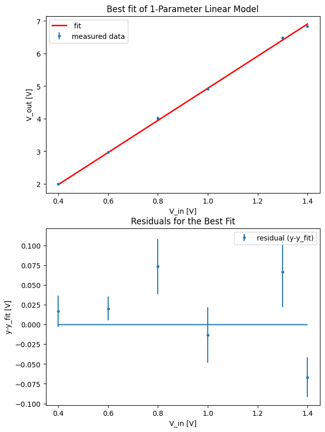

```python
# The script below fits to a sine wave, but can be modified for other functions
# First, we load some python packages
import matplotlib.pyplot as plt
import numpy as np
from scipy.optimize import curve_fit

################################################
# LIST OF ALL INPUTS
################################################

# fname is assumed to be in a four-column .csv file (comma separated values). The first two rows are
# assumed to be headers, like those produced in our code for packing oscilloscope data.
# The four columns are x-values, x-uncertainties, y-values, y-uncertainties.
# The .csv file must be in the same
# folder as this fit program, otherwise the full file extension must be added
# to fname: e.g. fname = 'folder/subfolder/subsubfolder/file.csv'

fname = "part1Gain2.csv"

x_name = "V_in"
x_units = "V"
y_name = "V_out"
y_units = "V"

# The model you will fit to is defined below, in this case a sine wave.
# The parameters in the model are amplitude, freqency, and phase.
# To get a least squares fitting process started, it is necessary to provide good
# initial guesses for the parameters. From your plots of the data so far, you can make good guesses at these parameters.

param_names = ["slope"]


# definition of the fit function
# def fit_function(x, amplitude,tau):

# fit function is a linear model with slope and intercept

def fit_function(x, slope):
    return x*slope

# load the file "fname", defined above# load the file "fname", defined above;
# if you have file with more than 4 columns, you may need to select different indicies for "usecols" (starting counting at 0)

data = np.loadtxt(fname, delimiter=",", comments="#", usecols=(0, 1, 2, 3), skiprows=2)

################################################
# READ IN DATA COLUMNS
################################################

# Here is where you access the data columns.
# You may need to alter these to choose what is on the y-axis and what is on the x-axis.

x = data[:, 0]
y = data[:, 2]
y_sigma = data[:, 3]

# calculate the best fit slope analytically (1-parameter solution)
m = sum(x*y/y_sigma**2)/sum((x/y_sigma)**2)

# calculate uncertainty of the best fit slope
m_sigma = np.sqrt(1/sum((x/y_sigma)**2))

print ("Slope is", m, "+/-", m_sigma)

###############################################################################
# calculates and prints the chi-squared, degrees of freedon, and weighted chi-squared
###############################################################################

# function that  calculates the chi square value of a fit
def chi_square (param1, x, y, sigma):
#
    return np.sum((y-fit_function(x, param1))**2/sigma**2)

# calculate and print chi square as well as the per degree-of-freedom value
chi2 = chi_square(m,x,y,y_sigma)
# degrees of freedom is the number of data points minus the number of parameters
dof = len(x) - 1
print ("\nGoodness of fit - Chi-squared measure:")
print ("degrees of freedom = {}, Chi2/dof = {}\n".format(dof, chi2/dof))


# residual is the difference between the data and model
x_fitfunc = np.linspace(min(x), max(x), 500)
y_fitfunc = fit_function(x_fitfunc, m)
y_fit = fit_function(x, m)
residual = y-y_fit
# creates a histogram of the residuals
# hist,bins = np.histogram(residual,bins=30)

fig = plt.figure(figsize=(7,10))

ax1 = fig.add_subplot(211)
ax1.errorbar(x,y,yerr=y_sigma,marker='.',linestyle='',label="measured data")
ax1.plot(x_fitfunc,y_fitfunc,marker="",linestyle="-",linewidth=2,color="r",
         label=" fit")
# add axis labels and title
ax1.set_xlabel('{} [{}]'.format(x_name,x_units))
ax1.set_ylabel('{} [{}]'.format(y_name,y_units))
ax1.set_title('Best fit of 1-Parameter Linear Model')
# set the x and y boundaries of your plot
#plt.xlim(lower_x,upper_x)
#plt.ylim(lower_y,upper_y)
# show a legend. loc='best' places legend where least amount of data is
# obstructed.
ax1.legend(loc='best',numpoints=1)


# this code produces a figure with a plot of the residuals as well
# as a histogram of the residuals.
# fig = plt.figure(figsize=(7,10))
ax2 = fig.add_subplot(212)
ax2.errorbar(x,residual,yerr=y_sigma,marker='.',linestyle='',
             label="residual (y-y_fit)")
ax2.hlines(0,np.min(x),np.max(x),lw=2,alpha=0.8)
ax2.set_xlabel('{} [{}]'.format(x_name,x_units))
ax2.set_ylabel('y-y_fit [{}]'.format(y_units))
ax2.set_title('Residuals for the Best Fit')
ax2.legend(loc='best',numpoints=1)

# ax3 = fig.add_subplot(313)
# ax3.bar(bins[:-1],hist,width=bins[1]-bins[0])

# ax3.set_ylim(0,1.2*np.max(hist))
# ax3.set_xlabel('y-y_fit [{}]'.format(y_units))
# ax3.set_ylabel('Number of occurences')
# ax3.set_title('Histogram of the Residuals')

"""
Modify the following lines to change the name of the file used to store a JPEG of your best fit graphs
"""

# Before showing the plot, you can also save a copy of the figure as a JPEG.
# The order is important here because plt.show clears the plot information after displaying it.
plt.savefig('FittingResults.jpeg')
plt.show()
```

**Notes about gain**

- The linear plot looks good. There are some data points that are not exactly linear but that is fine in an experiment. The residuals don't show any obvious pattern which is good. The $\chi^2 \approx 3.26 >> 1$ indicates that uncertainties might have been underestimated.
- Gain = $\frac{V_{out}}{V_{in}}$
- From the plots we get a slope of $4.9 \pm 0.01$. This slope shows the **gain** of our amplifier.

#### Notes about frequency response of our amplifier

- It is essential that for a given small $V_{in}$, $V_{out}$ must stay undistorted. We tested our amplifier over a large range.
- The output was perfect at $20~kHz$ (human hearing range). The plot below shows that there is no distortion at $20~kHz$. We can also see that the gain is about what we saw in the linear plot's slope.

[figure not shown]

#### Notes about effect of DC offset in $V_{in}$ on $V_{out}$ without the capacitor.

- We ensured that CH1 (function generator) and CH2 (oscilloscope around the circuit) were DC coupled for this test.
- We didn't observe any noticeable distortion for the range $0~\text{to}~0.5~V$. We noticed slight distotion at $0.6~V$ and very clear distortion at $0.7~V$. The image below shows the screenshot of the oscilloscope which shows clear distortion at $0.7~V$ offset. We are using a frequency of $1~kHz$ for $V_{in}$.

[figure not shown]

#### Notes about effect of DC offset in $V_{in}$ on $V_{out}$ with the $0.01~ \mu F$ capacitor.

- Adding the capacitor removes the distortion by the DC offset. This is because once the capacitor, it doesn't let the DC current flow and the distortion disappears. The image below shows that even at $1~V$ DC offset, there is no distortion in the output. We are using a frequency of $1~kHz$ for $V_{in}$.

[figure not shown]

#### Freqency vs $V_{out} plot$

- We plot the frequency vs $V_{out}$ to see where the gain gets flat.
- We are able to do this through plot because $\text{gain}~= \frac{V_{out}}{V_{in}}$, i.e. if $V_{in}$ is constnat (which we ensure is) then gain is flat where $V_{out}$ is flat.

```python
freqGain = de.sheet("freqGain.csv")
```

```
Sheet name: freqGain.csv
```

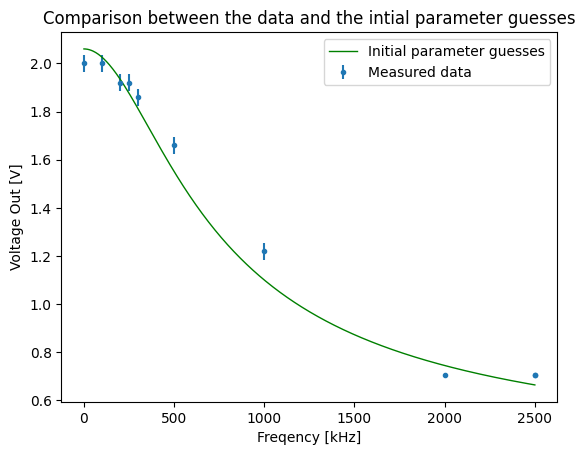

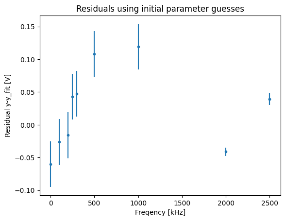

```
Chi-squared =  16.250167227074392

Fit parameters:
   f0 = 3.182e-04 ± 1.774e-05
   Vin = 1.736e+00 ± 2.311e-02
   gamma = 3.241e-01 ± 2.348e-02
```

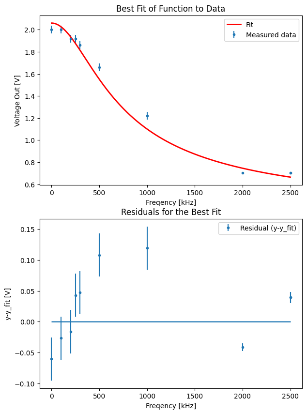

```python
# Load python packages
import matplotlib.pyplot as plt
import numpy as np
from scipy.optimize import curve_fit

###############################################################################
# DEFINED FITTING FUNCTIONS
###############################################################################

def sine_func(x, amplitude, freq, phase):
    return amplitude * np.sin(2.0 * np.pi * freq * x + phase)

def offset_sine_func(x, amplitude, freq, phase, offset):
    return (amplitude * np.sin(2.0 * np.pi * freq * x + phase)) + offset

def exponential_func(x, amplitude, tau, voffset):
    return amplitude * np.exp(x/(-1.0*tau)) + voffset

def ringdown_function(x, amplitude, tau, resonantf, phase):
    return amplitude * np.exp(-x/tau) * np.cos(2.0*np.pi * resonantf * x + phase)

def linear_func(x, slope, intercept):
    return slope * x + intercept

def RCresp_func(x, tau, V0, voffset):
    return V0/(np.sqrt(1+(2*np.pi*tau*x)**2)) + voffset

def LRCresp_func(x, f0, Vin, gamma):
    return Vin/(np.sqrt(1+(2*np.pi/(gamma*x))**2*(x**2-f0**2)**2))

###############################################################################
# LIST OF ALL INPUTS
###############################################################################

# Name of the data file
fname = "freqGain.csv"

# Names and units of data columns from fname
x_name = "Freqency"
x_units = "kHz"
y_name = "Voltage Out"
y_units = "V"

# Modify to change the fitting function, parameter names and to set initial parameter guesses
fit_function = RCresp_func
param_names = ("f0", "Vin", "gamma")
guesses = (3.182e-04, 1.736e+00, 3.241e-01)

# Flags for optional features
show_covariance_matrix = False
set_xy_boundaries = False
lower_x = -0.01 # these values ignored if set_xy_boundaries = False
upper_x = 0.01
lower_y = -1
upper_y = 1

###############################################################################
# LOAD DATA
###############################################################################

# load the file fname and skip the first 'skiprows' rows
data = np.loadtxt(fname, delimiter=",", comments="#", usecols=(0, 1, 2, 3), skiprows=2)

# Assign the data file columns to variables for later use
x = data[:, 0]
y = data[:, 2]
y_sigma = data[:, 3]

###############################################################################
# INITIAL PLOT OF THE DATA
###############################################################################

# Define 500 points spanning the range of the x-data; for plotting smooth curves
xtheory = np.linspace(min(x), max(x), 500)

# Compare the guessed curve to the data for visual reference
y_guess = fit_function(xtheory, *guesses)
plt.errorbar(x, y, yerr=y_sigma, marker=".", linestyle="", label="Measured data")
plt.plot(
    xtheory,
    y_guess,
    marker="",
    linestyle="-",
    linewidth=1,
    color="g",
    label="Initial parameter guesses",
)
plt.xlabel(f"{x_name} [{x_units}]")
plt.ylabel(f"{y_name} [{y_units}]")
plt.title(r"Comparison between the data and the intial parameter guesses")
plt.legend(loc="best", numpoints=1)
plt.show()

# calculate the value of the model at each of the x-values of the data set
y_fit = fit_function(x, *guesses)

# Residuals are the difference between the data and theory
residual = y - y_fit

# Plot the residuals
plt.errorbar(x, residual, yerr=y_sigma, marker=".", linestyle="", label="residuals")
plt.xlabel(f"{x_name} [{x_units}]")
plt.ylabel(f"Residual y-y_fit [{y_units}]")
plt.title("Residuals using initial parameter guesses")
plt.show()

###############################################################################
# PERFORM THE FIT AND PRINT RESULTS
###############################################################################

# Use curve_fit to perform the fit
# fit_function: defined above to choose a specific fitting function
# fit_params: holds the resulting fit parameters
# fit_cov: the covariance matrix between all the parameters
#          (used to extract fitting parameter uncertanties)
# maxfev=10**5: maximum number of fitting procedure iterations before giving up
# absolute_sigma=True: uncertainties are treated as absolute (not relative)
fit_params, fit_cov = curve_fit(
    fit_function, x, y, sigma=y_sigma,
    p0=guesses,absolute_sigma=True, maxfev=10**5)

# Define the function that calculates chi-squared
def chi_square(fit_parameters, x, y, sigma):
    dof = len(x) - len(fit_params)
    return np.sum((y - fit_function(x, *fit_parameters)) ** 2 / sigma**2)/dof

# Calculate and print reduced chi-squared
chi2 = chi_square(fit_params, x, y, y_sigma)
print("Chi-squared = ", chi2)

# Calculate the uncertainties in the fit parameters
fit_params_error = np.sqrt(np.diag(fit_cov))

# Print the fit parameters with uncertianties
print("\nFit parameters:")
for i in range(len(fit_params)):
    print(f"   {param_names[i]} = {fit_params[i]:.3e} ± {fit_params_error[i]:.3e}")
print("\n")

# (Optional) Print the covariance between all variables
if show_covariance_matrix:
    print("Covariance between fit parameters:")
    for i, fit_covariance in enumerate(fit_cov):
        for j in range(i+1,len(fit_covariance)):
            print(f"   {param_names[i]} and {param_names[j]}: {fit_cov[i,j]:.3e}")
    print("\n")

# residual is the difference between the data and model
x_fitfunc = np.linspace(min(x), max(x), 500) # uses fine mesh to plot the function smoothly
y_fitfunc = fit_function(x_fitfunc, *fit_params)
y_fit = fit_function(x, *fit_params) # uses x values from data
residual = y-y_fit

###############################################################################
# PRODUCE A MULTIPANEL PLOT, WITH SCATTER PLOT, RESIDUALS AND RESIDUALS HISTOGRAM
###############################################################################

# The size of the canvas
fig = plt.figure(figsize=(7,10))

# The scatter plot
ax1 = fig.add_subplot(211)
ax1.errorbar(x,y,yerr=y_sigma,marker='.',linestyle='',label="Measured data")
ax1.plot(x_fitfunc, y_fitfunc, marker="", linestyle="-", linewidth=2,color="r", label="Fit")
ax1.set_xlabel(f"{x_name} [{x_units}]")
ax1.set_ylabel(f"{y_name} [{y_units}]")
ax1.set_title('Best Fit of Function to Data')

# (Optional) set the x and y boundaries of your plot
if set_xy_boundaries:
    plt.xlim(lower_x,upper_x)
    plt.ylim(lower_y,upper_y)
# Show the legend. loc='best' places it where the date are least obstructed
ax1.legend(loc='best',numpoints=1)

# The residuals plot
ax2 = fig.add_subplot(212)
ax2.errorbar(x, residual, yerr=y_sigma,marker='.', linestyle='', label="Residual (y-y_fit)")
ax2.hlines(0,np.min(x),np.max(x),lw=2,alpha=0.8)
ax2.set_xlabel(f"{x_name} [{x_units}]")
ax2.set_ylabel(f"y-y_fit [{y_units}]")
ax2.set_title('Residuals for the Best Fit')
ax2.legend(loc='best',numpoints=1)

# Histogram of the residuals -- commented out in 2025; deemed extraneous, look at distribution of residuals in above plot instead
# ax3 = fig.add_subplot(313)
# hist,bins = np.histogram(residual,bins=30)
# ax3.bar(bins[:-1],hist,width=bins[1]-bins[0])
# ax3.set_ylim(0,1.2*np.max(hist))
# ax3.set_xlabel(f"y-y_fit [{y_units}]")
# ax3.set_ylabel('Number of occurences')
# ax3.set_title('Histogram of the Residuals')

# Save a copy of the figure as a png
plt.savefig('FittingResults.png')

# Show the plot
plt.show()
```

### Part 2: Demodulation-rectifier/ low pass filter

#### Component list

- Ge diode: confirmed that the turn-on voltage is $0.3~V$
- $0.5~nF$ capacitor
- $100~k\Omega$ resistor

#### Setup

- Build the circuit as shown in the diagram. We ensured that the diode is forward biased (from left to right as shown in the diagram).
- Set the function generator frequency to $690~kHz$ and amplitude to $0.5~V$. Use an amplitude modulation of $6.9~kHz$.

#### Notes about Demodulation-rectifier/low pass filter

- We first use the oscillosclope to make measurement across the diode. Since the diode only lets current flow in one direction, the signal gets rectified. The rectified signal is shown in the image below. We see the sinusoidal wave pattern is rectified.

[figure not shown]

- After adding the filter circuit to the oscilloscope measurement, we can see that the higher frequencies in the signal are removed. This is precisely why we call our RC filter a low-pass filter; it only lets low frequencies pass through the circuit. You can observe, in the following image, that the signal looks "cleaner".

[figure not shown]

  - Comparing the amplitude, offset, and frequency of the input signal with the output signal:
    - Amplitude: Amplitude of the output signal is (significantly) lower than the input signal
    - Frequency: Frequency of the output signal is the same as the input signal
    - DC offset: We notice that there is a DC offset in the output signal.
- After connecting the output of this circuit to the amplifier circuit (from part 1) we observe that the frequency and DC offset of the output signal don't change. The amplitude is amplified. This could be observed in the following image.

[figure not shown]

### Part 3: Tank Circuit

Date: 18 November 2025

#### Setup

- We buid the circuit as shown in the diagram.
- We wind a coil about about 10 turns tightly around the inductor and ground one end of the coil.
- The function generator was used to produce an AM signal with a $690~kHz$ carrier frequency at $0.5~V$ amplitude and a $6.9~kHz$ modulation frequency. The signal was applied to the coil through the $100~\omega$ resistor, with the generator ground connected to circuit ground.

#### Notes

- As we tune the $LC$ circuit using the variable capacitor, the resonant frequency of the $LC$ circuit changes. We see this on CH2 as we fidget with the variable capacitor. There comes a point when the amplitude of the variable circuit is maximized. This theoretically happens when the resonant frequency of the $LC$ circuit becomes equal to $690~kHz$ frequncy of input from the function generator.
- Image when the circuit in off resonance:

[figure not shown]

- Image when the circuit is on resonance:

[figure not shown]

#### $V_{out}$ vs varying frequencies of $V_{in}$

```python
tc = de.sheet('tc')
```

```
Sheet name: tc.csv
```

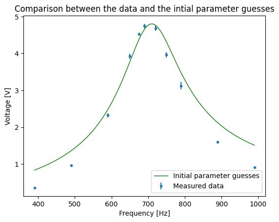

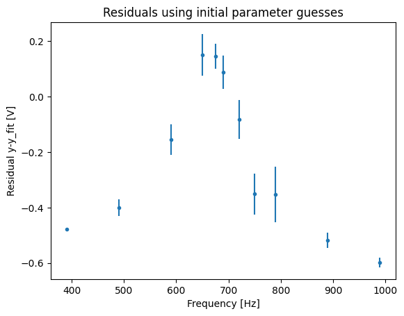

```
Chi-squared =  262.71483524167024

Fit parameters:
   f0 = 7.036e+02 ± 4.477e-01
   V = 5.762e+00 ± 6.166e-02
   gamma = 3.608e+02 ± 4.192e+00
```

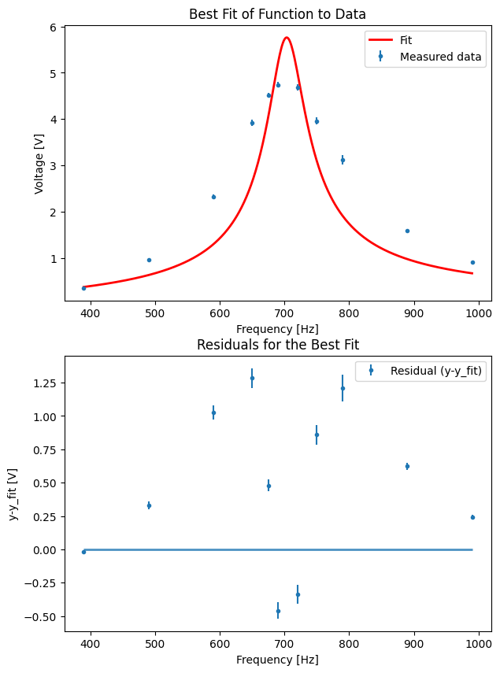

```python
# Load python packages
import matplotlib.pyplot as plt
import numpy as np
from scipy.optimize import curve_fit

###############################################################################
# DEFINED FITTING FUNCTIONS
###############################################################################

def sine_func(x, amplitude, freq, phase):
    return amplitude * np.sin(2.0 * np.pi * freq * x + phase)

def offset_sine_func(x, amplitude, freq, phase, offset):
    return (amplitude * np.sin(2.0 * np.pi * freq * x + phase)) + offset

def exponential_func(x, amplitude, tau, voffset):
    return amplitude * np.exp(x/(-1.0*tau)) + voffset

def ringdown_function(x, amplitude, tau, resonantf, phase):
    return amplitude * np.exp(-x/tau) * np.cos(2.0*np.pi * resonantf * x + phase)

def linear_func(x, slope, intercept):
    return slope * x + intercept

def RCresp_func(x, tau, V0, voffset):
    return V0/(np.sqrt(1+(2*np.pi*tau*x)**2)) + voffset

def LRCresp_func(x, f0, Vin, gamma):
    return Vin/(np.sqrt(1+(2*np.pi/(gamma*x))**2*(x**2-f0**2)**2))

###############################################################################
# LIST OF ALL INPUTS
###############################################################################

# Name of the data file
fname = "tc.csv"

# Names and units of data columns from fname
x_name = "Frequency"
x_units = "Hz"
y_name = "Voltage"
y_units = "V"

# Modify to change the fitting function, parameter names and to set initial parameter guesses
fit_function = LRCresp_func
param_names = ("f0", "V", "gamma")
guesses = (7.10e+02, 4.8, 1.0e+03)

# Flags for optional features
show_covariance_matrix = False
set_xy_boundaries = False
lower_x = -0.01 # these values ignored if set_xy_boundaries = False
upper_x = 0.01
lower_y = -1
upper_y = 1

###############################################################################
# LOAD DATA
###############################################################################

# load the file fname and skip the first 'skiprows' rows
data = np.loadtxt(fname, delimiter=",", comments="#", usecols=(0, 1, 2, 3), skiprows=2)

# Assign the data file columns to variables for later use
x = data[:, 0]
y = data[:, 2]
y_sigma = data[:, 3]

###############################################################################
# INITIAL PLOT OF THE DATA
###############################################################################

# Define 500 points spanning the range of the x-data; for plotting smooth curves
xtheory = np.linspace(min(x), max(x), 500)

# Compare the guessed curve to the data for visual reference
y_guess = fit_function(xtheory, *guesses)
plt.errorbar(x, y, yerr=y_sigma, marker=".", linestyle="", label="Measured data")
plt.plot(
    xtheory,
    y_guess,
    marker="",
    linestyle="-",
    linewidth=1,
    color="g",
    label="Initial parameter guesses",
)
plt.xlabel(f"{x_name} [{x_units}]")
plt.ylabel(f"{y_name} [{y_units}]")
plt.title(r"Comparison between the data and the intial parameter guesses")
plt.legend(loc="best", numpoints=1)
plt.show()

# calculate the value of the model at each of the x-values of the data set
y_fit = fit_function(x, *guesses)

# Residuals are the difference between the data and theory
residual = y - y_fit

# Plot the residuals
plt.errorbar(x, residual, yerr=y_sigma, marker=".", linestyle="", label="residuals")
plt.xlabel(f"{x_name} [{x_units}]")
plt.ylabel(f"Residual y-y_fit [{y_units}]")
plt.title("Residuals using initial parameter guesses")
plt.show()

###############################################################################
# PERFORM THE FIT AND PRINT RESULTS
###############################################################################

# Use curve_fit to perform the fit
# fit_function: defined above to choose a specific fitting function
# fit_params: holds the resulting fit parameters
# fit_cov: the covariance matrix between all the parameters
#          (used to extract fitting parameter uncertanties)
# maxfev=10**5: maximum number of fitting procedure iterations before giving up
# absolute_sigma=True: uncertainties are treated as absolute (not relative)
fit_params, fit_cov = curve_fit(
    fit_function, x, y, sigma=y_sigma,
    p0=guesses,absolute_sigma=True, maxfev=10**5)

# Define the function that calculates chi-squared
def chi_square(fit_parameters, x, y, sigma):
    dof = len(x) - len(fit_params)
    return np.sum((y - fit_function(x, *fit_parameters)) ** 2 / sigma**2)/dof

# Calculate and print reduced chi-squared
chi2 = chi_square(fit_params, x, y, y_sigma)
print("Chi-squared = ", chi2)

# Calculate the uncertainties in the fit parameters
fit_params_error = np.sqrt(np.diag(fit_cov))

# Print the fit parameters with uncertianties
print("\nFit parameters:")
for i in range(len(fit_params)):
    print(f"   {param_names[i]} = {fit_params[i]:.3e} ± {fit_params_error[i]:.3e}")
print("\n")

# (Optional) Print the covariance between all variables
if show_covariance_matrix:
    print("Covariance between fit parameters:")
    for i, fit_covariance in enumerate(fit_cov):
        for j in range(i+1,len(fit_covariance)):
            print(f"   {param_names[i]} and {param_names[j]}: {fit_cov[i,j]:.3e}")
    print("\n")

# residual is the difference between the data and model
x_fitfunc = np.linspace(min(x), max(x), 500) # uses fine mesh to plot the function smoothly
y_fitfunc = fit_function(x_fitfunc, *fit_params)
y_fit = fit_function(x, *fit_params) # uses x values from data
residual = y-y_fit

###############################################################################
# PRODUCE A MULTIPANEL PLOT, WITH SCATTER PLOT, RESIDUALS AND RESIDUALS HISTOGRAM
###############################################################################

# The size of the canvas
fig = plt.figure(figsize=(7,10))

# The scatter plot
ax1 = fig.add_subplot(211)
ax1.errorbar(x,y,yerr=y_sigma,marker='.',linestyle='',label="Measured data")
ax1.plot(x_fitfunc, y_fitfunc, marker="", linestyle="-", linewidth=2,color="r", label="Fit")
ax1.set_xlabel(f"{x_name} [{x_units}]")
ax1.set_ylabel(f"{y_name} [{y_units}]")
ax1.set_title('Best Fit of Function to Data')

# (Optional) set the x and y boundaries of your plot
if set_xy_boundaries:
    plt.xlim(lower_x,upper_x)
    plt.ylim(lower_y,upper_y)
# Show the legend. loc='best' places it where the date are least obstructed
ax1.legend(loc='best',numpoints=1)

# The residuals plot
ax2 = fig.add_subplot(212)
ax2.errorbar(x, residual, yerr=y_sigma,marker='.', linestyle='', label="Residual (y-y_fit)")
ax2.hlines(0,np.min(x),np.max(x),lw=2,alpha=0.8)
ax2.set_xlabel(f"{x_name} [{x_units}]")
ax2.set_ylabel(f"y-y_fit [{y_units}]")
ax2.set_title('Residuals for the Best Fit')
ax2.legend(loc='best',numpoints=1)

# Histogram of the residuals -- commented out in 2025; deemed extraneous, look at distribution of residuals in above plot instead
# ax3 = fig.add_subplot(313)
# hist,bins = np.histogram(residual,bins=30)
# ax3.bar(bins[:-1],hist,width=bins[1]-bins[0])
# ax3.set_ylim(0,1.2*np.max(hist))
# ax3.set_xlabel(f"y-y_fit [{y_units}]")
# ax3.set_ylabel('Number of occurences')
# ax3.set_title('Histogram of the Residuals')

# Save a copy of the figure as a png
plt.savefig('FittingResults.png')

# Show the plot
plt.show()
```

##### Notes about the fit

```python
gamma = 361
L =  450 * 10e-6
Reff = gamma * L
print(Reff)
```

```
1.6245000000000003
```

### Part 4: Listening to the radio

- After completing the circuit, we disconnect the circuit from the function generator and oscilloscope and connect it to the antena and the speaker.
- We are successfully able to hear CBC radio.
- We tweaked with the capacitance of the variable capacitor while the circuit is connected to the speaker. An interesting observation was that when we changed the capacitance such that the resonant frequency of the LC circuit was not in resonacne with radio channel carrier frequency, the audio signal was not as loud but still audible. The audio somehow seemed clearer. I am not sure why; it might just be a placebo.
- Unfortunately, we missed the last screenshot.

### Summary/Conclusion

- We were successfully able to build a radio. I am really proud of the fact. It sounded well and performed as expected.
- The ampifier circuit we built was pretty clean. We were able to get a gain of $4.9 \pm 0.01$.
- I learned how the $Ge$ diode can be used as a recitfier and how I can use a low pass filter in the form of $RC$ circuit.
- The $LC$ circuit could be used to intercept the radio carrier signal and if the resonant frequency of our circuit matches the carrier frequency, we get a high amplitude of the signal which could then be passed to demodulator for demodulation and isolating the audio signal and then to the amplifier to amplify the signal so that we can drive the speaker.
- I also learned about how one should go about setting up a circuit cleanly on the breadboard. One must use color-coded wires with defined conventions (eg. red for +ve and black for ground) to make debugging easier.
- We should always try to neatly place the wires and the wires should be the right length. If the wires are too short, then it would be hard to properly put them in the breadboard. If they are too long, they will occupy too much space and will clutter the view of the circuit.
- If things go wrong with a circuit with multiple parts, one needs to step back and try to isolate the issue by testing each sub-componet thoroughly. Doing this systematically and calmly usually leads to success.
- Being able to read cirucit diagrams and replicating that on the breadboard or being able to verify the circuit using the diagram is a crucial skill that takes time and patience.
- Radio circuit with the speaker

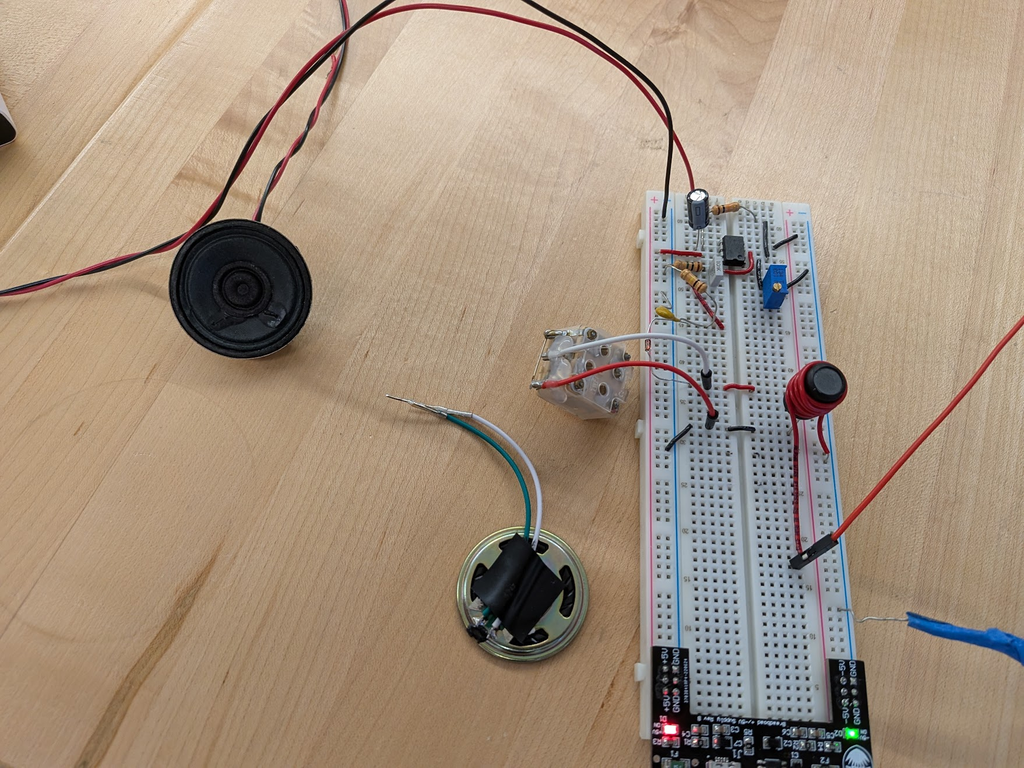

- Raido circuit with the oscilloscope and function generator

[figure not shown]

To the TAs: Thanks for supporting my journey throught PHYS 219. I appreciate your help in me getting through this term.

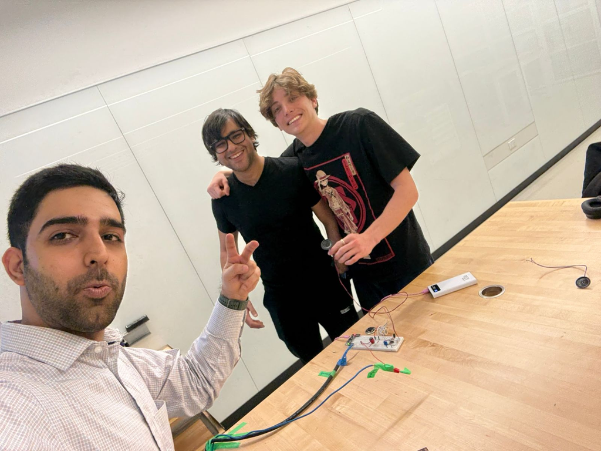

The following are the very minimal notes taken throughout the final radio project. I had to make changes in the formatting to make them understanable.

## Audio Amplifier (Op-Amp)

- Build a non-inverting amplifier using LF411
- Measure gain vs input amplitude
- Measure frequency response (audio range)
- Test effect of DC offset and AC-coupling capacitor

Part 1: Amplifier — Measurement Requirements

1. Verify operation
   - Apply ~200 mVpp, 1 kHz sine
   - View Vin (CH1) and Vout (CH2), confirm clean amplification (no distortion)
2. Gain vs Input Amplitude
   - Keep 1 kHz fixed
   - Increase Vin from small value until clipping
   - Record Vin and Vout
   - Plot Vout vs Vin and extract gain (slope)
   - Compare to theoretical gain = 1 + R2/R1
3. Frequency Response
   - Fix Vin small (~100 mVpp)
   - Sweep frequency ~100 Hz → >20 kHz
   - Record Vout and find where gain begins to drop (roll-off)
4. DC Offset Behavior
   - Apply DC offset to input without coupling capacitor, observe shift at output
   - Repeat with 0.01 µF capacitor in series, confirm DC is removed (signal recenters)

Deliverables:

- Table: Vin vs Vout
- Vout vs Vin plot with fitted gain
- Table: frequency vs gain and roll-off point
- Screenshots showing: normal operation, clipping, offset without capacitor, offset with capacitor

### Part 1 components

- R2: 9.9 Kohm
- R1: variable resistor
- 220 microF capacitor: 206.9 microF
- between part 1 and part2 -> 1Mohm Resistor: 1.001 MOhm

### Part 2 components

- 0.5 nN capacitor = 0.473 nF
- 100 kOhm resistor = 100.5 kOhm
- Range where Vin vs Vout is undistorted: -600 mVpp to 700 mVpp
- 20kHz frequency is fine for our circuit
- With the capacitor, the change in offset doesn't shift the output channel

## AM Demodulator (Diode + RC Low-Pass Filter)

- Build diode detector circuit
- Apply AM signal (690 kHz carrier, ~6.9 kHz modulation)
- Observe rectified output and filtered audio output
- Feed output into amplifier and compare waveforms

### Part 3 Components

- Inductor: 450 microH
- 24 to 240 pF capacitor
- 100 ohm resistor: 99.5 Ohm (across the coil)
1. Again, you use the function generator to create an AM signal. The modulated signal from the function generator is applied to the coil by connecting the voltage signal to the 100 Ohm resistor and the ground side of the function generator to the circuit ground. Once again, use a frequency of 690 kHz, an amplitude of 0.5 V, and amplitude modulation at 6.9 kHz.
2. The signal from the function generator drives a current through the 100 Ohm resistor and the coil wrapped around the inductor. Observe the function generatir signal on Ch1 of your oscil- loscope. The output signal from the amplifier is used to monitor the resonance and should be connected to CH2. Now adjust the capacitor slowly to maximize the output amplitude. An ex- ample of what you should see close to resonance is shown in Fig. 6 . Save images of the signal on resonance and well off resonance. Describe what is observed as you vary the capacitance slowly through the resonance.